# Check Point #002

@codedtrader

2025-05-11

# **Crypto Weekly Intelligence Brief**

## **Is the Recent Pump a Relief Rally or the Beginning of a Parabolic Run?**

This week’s market activity has sparked debates across the crypto space. BTC led a sharp pump, but underlying data continues to raise serious caution flags, especially for altcoins.

### **Macro Event: FOMC Meeting**

- The Fed kept interest rates unchanged, aligning with market expectations.
- Journalists pushed for a clear hawkish/dovish label — but Powell held a neutral tone, emphasizing that current data does not support any shift in policy yet.
- Powell: *“We need more clarity before making a decision.”*

### **Crypto Market Conditions**

#### **Risk Metrics Spiked**

Over the past week, the Sortino ratios for major assets have shown a significant upward trend, highlighting a broad improvement in risk-adjusted returns. The shift began subtly in late April and accelerated into early May, with May 8th and 10th marking a sharp expansion in favorable risk conditions across BTC, SUI, and key altcoins. This regime shift suggests growing market confidence, with downside volatility decreasing relative to returns. While individual asset performance varies, the general trend points toward a more constructive environment for swing positioning.

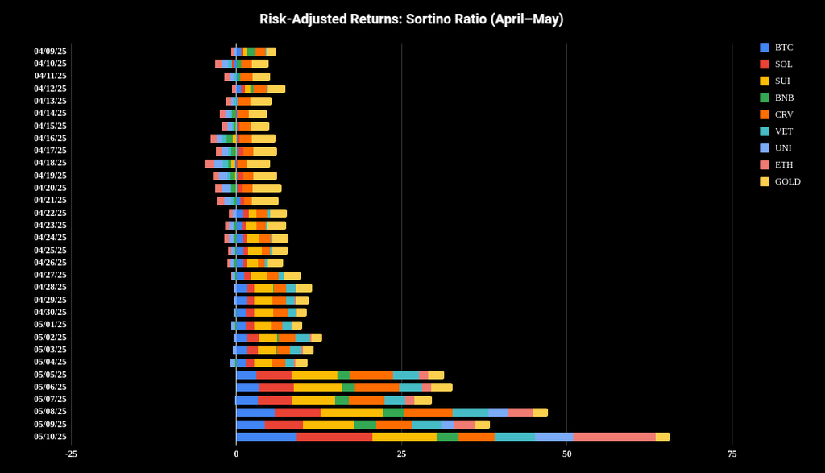

Improving Risk-Adjusted Returns

#### **Bitcoin Liquidation Heatmap Insight – Key Level: $105,000**

The most intense heat concentration appears at the $105K price level, indicating a major liquidity cluster. This zone is likely to act as a magnet for price action, potentially drawing price toward it due to the high density of stop orders and liquidations. It may serve as a resistance area or a target for large players, making it a key level to watch for breakouts, reversals, or stop hunts.

[figure not shown]

Source: https://coinank.com/liqHeatMapChart/btcusdt/3d

#### **Short-Term Holder MVRV Signals Bullish Continuation**

The BTC Short-Term Holder MVRV ratio has recently broken above the 1.0 level (cost basis) and crossed the mid-band (mean) of its historical standard deviation channel. This indicates that short-term holders are back in profit, which historically aligns with early bull phases or continuation rallies.

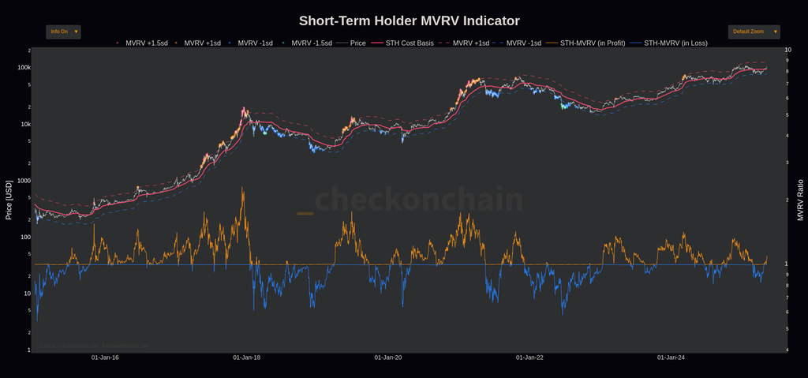

Source: https://charts.checkonchain.com/btconchain/unrealised/sthmvrv_indicator/sthmvrv_indicator_dark.html

### **Altcoin Signal Layer Update**

Ethereum is currently leading altcoins in terms of momentum and risk-adjusted performance. This suggests growing investor interest and potential early positioning in ETH. However, a notable red flag emerges from the Dynamic Return Asymmetry Signal (DRAS), which has plunged to an extreme -1524.95%.

In summary, ETH is currently the altcoin to watch, but traders should be cautious. Strong performance may be masking a brewing volatility imbalance that could reverse sharply if BTC retraces or if macro sentiment weakens.

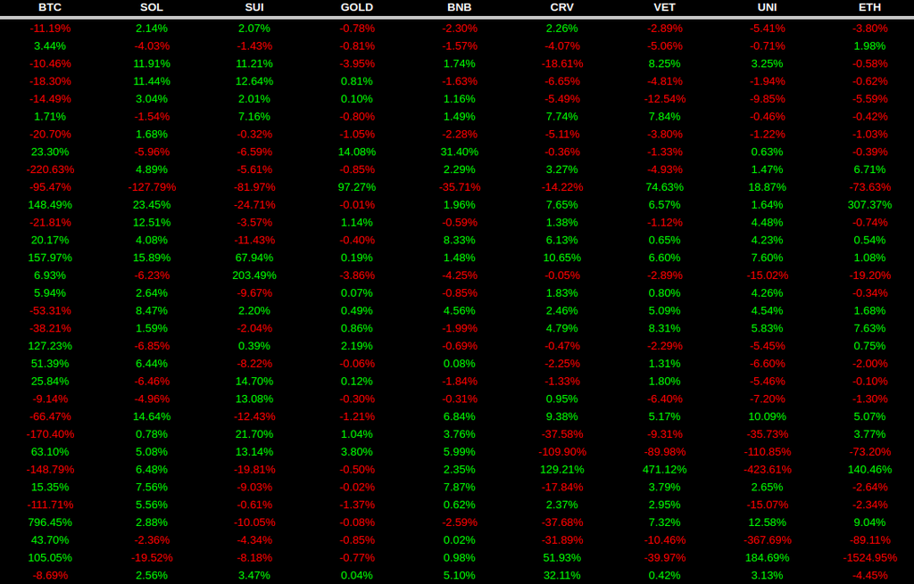

Dynamic Return Asymmetry Signal (DRAS)

Comparative Risk & Distribution Metrics for Market Assessment (05/10/2025)

| Assets | Volatility | Skewness |
| --- | --- | --- |
| BTC | 2.06% | -0.04076 |
| SPX | 1.34% | -0.67371 |
| DXY | 0.46% | -1.4643 |
| AUX | 1.96% | 1.90227 |
| SOL | 3.98% | -0.35162 |
| SUI | 5.42% | 0.24838 |
| ETH | 3.7% | 0.74924 |

### **Market Thesis:**

BTC is drifting upward within a consolidating range, but key signals — including declining skewness & negative momentum relative to DXY, suggest that this move is not underpinned by sustainable strength.

Meanwhile, SPX price action diverges from BTC, reinforcing the view that crypto may be temporarily decoupled from broader risk sentiment. However, with DXY deeply oversold and Powell emphasizing “muddy data,” macro clarity remains elusive — and a resurgence in dollar strength or hawkish policy expectations could hit risk assets hard.

Altcoins remain structurally weak, given the size of 5+ year BTC HODLers and the significant percentage of Bitcoin dominance relative to the TOTAL crypto market cap, it is unlikely that Alts will experience a parabolic move without a decisive BTC-led breakout. In fact, any minor retracement in BTC could result in outsized downside across altcoins.

[figure not shown]

5 years + HODLers | Source: https://charts.bitbo.io/5y-hodl-wave/

### **Conclusion:**

Despite the strong improvement in risk-adjusted returns, as reflected by the rising Sortino ratios across key assets, recent developments signal a potential pause. Liquidation levels have been reached, momentum has slightly cooled, and our market regime indicator has shifted to mean-reverting. These signs suggest the market may be due for a short-term retracement before resuming its upward trajectory. We remain watchful for confirmation before repositioning aggressively.

##### **Novices panic and react while real Gs observe then act.**

##### *Disclaimer:*

*The information and analysis provided are for informational and educational purposes only and should not be considered financial, investment, or trading advice.*

*Cryptocurrency markets are highly volatile and subject to rapid price fluctuations, regulatory changes, and unforeseen events. The Efficient Market Hypothesis (EMH) suggests that market prices reflect all available information, making it challenging to consistently outperform the market.*

*Investing or trading in financial markets, especially cryptocurrencies, involves significant risk. There is no guarantee of profits, and you may lose some or all of your invested capital. Past performance is not indicative of future results.*

*You are solely responsible for your financial decisions. Always conduct your own research, consult with a certified financial advisor, and carefully assess your risk tolerance before making any investment decisions.*

*By engaging with our services, you acknowledge and accept these risks.*